# Magic: The Gathering EDA

Josh Folsom

### Data Exploration of MTG Data Set

#### This report explores a dataset containing a variety of attributes for approximately 39,000 Magic: The Gathering Cards

###### Data from https://github.com/yhejazi/mtg-web-scraper thanks to Yasmine Hejazi

###### Description stored in MTGPackage

### Univariate Exploration

##### The first thing I wanted to do was load in my dataset, and then check the attributes this dataset included, so I could get an idea of where I would like to explore. Though some of these are fairly self-explanatory a few others were just abstract enough that I wanted to get a better footing before diving in. One thing I do notice immediately that has me slightly concerned is the max value of 1,000,000 in convertedMana.

```
##    cardName          superType           cardType           subType
##  Length:39050       Length:39050       Length:39050       Length:39050
##  Class :character   Class :character   Class :character   Class :character
##  Mode  :character   Mode  :character   Mode  :character   Mode  :character
##
##
##
##    typeNum            manaCost         convertedMana        cardSet
##  Length:39050       Length:39050       Min.   :0.00e+00   Length:39050
##  Class :character   Class :character   1st Qu.:2.00e+00   Class :character
##  Mode  :character   Mode  :character   Median :3.00e+00   Mode  :character
##                                        Mean   :2.87e+01
##                                        3rd Qu.:4.00e+00
##                                        Max.   :1.00e+06
##     rarity             rules
##  Length:39050       Length:39050
##  Class :character   Class :character
##  Mode  :character   Mode  :character
##
##
##
```

#### I took a sampling of the data so I could parse out what I’m dealing with

```
## 'data.frame':    39050 obs. of  10 variables:
##  $ cardName     : chr  "\"Ach! Hans, Run!\"" "\"Rumors of My Death . . .\"" "_____" "A Good Thing" ...
##  $ superType    : chr  "" "" "" "" ...
##  $ cardType     : chr  "Enchantment" "Enchantment" "Creature" "Enchantment" ...
##  $ subType      : chr  "" "" "Shapeshifter" "" ...
##  $ typeNum      : chr  "" "" "1/1" "" ...
##  $ manaCost     : chr  "2RRGG" "2B" "1U" "4WB" ...
##  $ convertedMana: int  6 3 2 6 2 3 0 3 3 4 ...
##  $ cardSet      : chr  "Unhinged" "Unstable" "Unhinged" "Mystery Booster" ...
##  $ rarity       : chr  "Rare" "Uncommon" "Uncommon" "Common" ...
##  $ rules        : chr  "At the beginning of your upkeep, you may say \"Ach Hans, run It's the . . .\" and the name of a creature card. "| __truncated__ "3B, Exile a permanent you control with a League of Dastardly Doom watermark: Return a permanent card with a Lea"| __truncated__ "1: This card's …
```

#### Rereleased Cards

```
## # A tibble: 6 x 2
##   cardName       count
##   <chr>          <int>
## 1 Mountain         123
## 2 Forest           120
## 3 Island           119
## 4 Plains           118
## 5 Swamp            118
## 6 Evolving Wilds    31
```

##### The higher the count, the more often that particular card has reappeared over the years

```
##    cardName             count
##  Length:21337       Min.   :  1.00
##  Class :character   1st Qu.:  1.00
##  Mode  :character   Median :  1.00
##                     Mean   :  1.83
##                     3rd Qu.:  2.00
##                     Max.   :123.00
```

```
##    cardName             count
##  Length:1206        Min.   :  5.000
##  Class :character   1st Qu.:  5.000
##  Mode  :character   Median :  6.000
##                     Mean   :  7.863
##                     3rd Qu.:  8.000
##                     Max.   :123.000
```

```
##    cardName             count
##  Length:216         Min.   : 10.00
##  Class :character   1st Qu.: 10.00
##  Mode  :character   Median : 12.00
##                     Mean   : 15.68
##                     3rd Qu.: 15.00
##                     Max.   :123.00
```

##### Typically they would appear more than once if they were released in a different set, I was impressed to see that over 200 cards have seen more than 10 appearances. Because of the large amount of duplicates I will need to be cognizant of performance impacts as well as whether I consider duplicates to be a valid(or invalidating) factor on my analyses.

#### Converted Mana Cost

```
## mtg$cardType:
##    Min. 1st Qu.  Median    Mean 3rd Qu.    Max.
##       0       0       0       0       0       0
## ------------------------------------------------------------
## mtg$cardType: Artifact
##      Min.   1st Qu.    Median      Mean   3rd Qu.      Max.
##       0.0       2.0       3.0     352.6       4.0 1000000.0
## ------------------------------------------------------------
## mtg$cardType: Artifact Creature
##    Min. 1st Qu.  Median    Mean 3rd Qu.    Max.
##   0.000   3.000   4.000   4.065   5.000  16.000
## ------------------------------------------------------------
## mtg$cardType: Artifact Land
##    Min. 1st Qu.  Median    Mean 3rd Qu.    Max.
##       0       0       0       0       0       0
## ------------------------------------------------------------
## mtg$cardType: Creature
##    Min. 1st Qu.  Median    Mean 3rd Qu.    Max.
##   0.000   2.000   3.000   3.658   5.000  15.000
## ------------------------------------------------------------
## mtg$cardType: Enchantment
##    Min. 1st Qu.  Median    Mean 3rd Qu.    Max.
##   0.000   2.000   3.000   2.937   4.000  10.000
## ------------------------------------------------------------
## mtg$cardType: Enchantment Artifact
##    Min. 1st Qu.  Median    Mean 3rd Qu.    Max.
##   3.000   3.000   4.000   3.571   4.000   4.000
## ------------------------------------------------------------
## mtg$cardType: Enchantment Creature
##    Min. 1st Qu.  Median    Mean 3rd Qu.    Max.
##    1.00    3.00    3.00    3.61    5.00    8.00
## ------------------------------------------------------------
## mtg$cardType: Enchantment Land
##    Min. 1st Qu.  Median    Mean 3rd Qu.    Max.
##       0       0       0       0       0       0
## ------------------------------------------------------------
## mtg$cardType: Instant
##    Min. 1st Qu.  Median    Mean 3rd Qu.    Max.
##   0.000   1.000   2.000   2.529   3.000  14.000
## ------------------------------------------------------------
```

[output cut: 20 more lines]

```
## mtg$cardType: Tribal Artifact
##    Min. 1st Qu.  Median    Mean 3rd Qu.    Max.
##     2.0     2.0     2.0     2.4     3.0     3.0
## ------------------------------------------------------------
## mtg$cardType: Tribal Enchantment
##    Min. 1st Qu.  Median    Mean 3rd Qu.    Max.
##   2.000   2.000   2.000   2.885   3.000   8.000
## ------------------------------------------------------------
## mtg$cardType: Tribal Instant
##    Min. 1st Qu.  Median    Mean 3rd Qu.    Max.
##   1.000   1.500   2.000   2.571   3.000   7.000
## ------------------------------------------------------------
## mtg$cardType: Tribal Sorcery
##    Min. 1st Qu.  Median    Mean 3rd Qu.    Max.
##   1.000   4.000   4.000   4.269   5.750   7.000
```

##### The above summary showed me that my ‘million outlier’ was an artifact. and the next highest card type has a value of 16.

##### Because I wanted to see the shape of the data by Converted Mana Cost (CMC) I created a simple histogram with CMC limited to an upper bound of 20

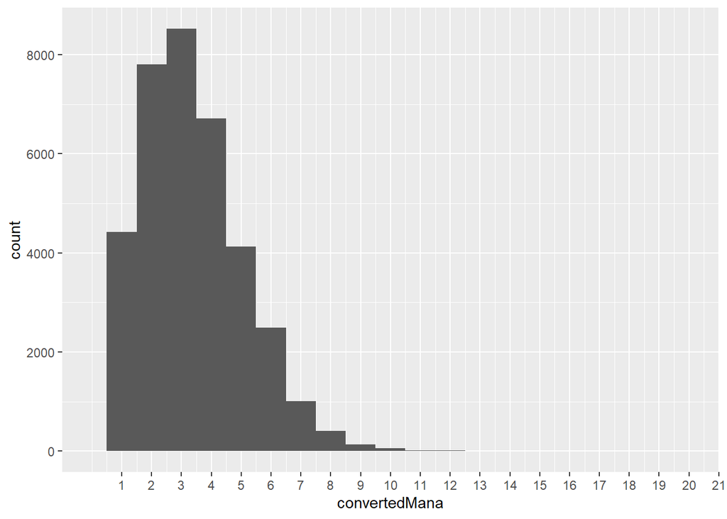

##### I also want to see the spread of cards by rarity

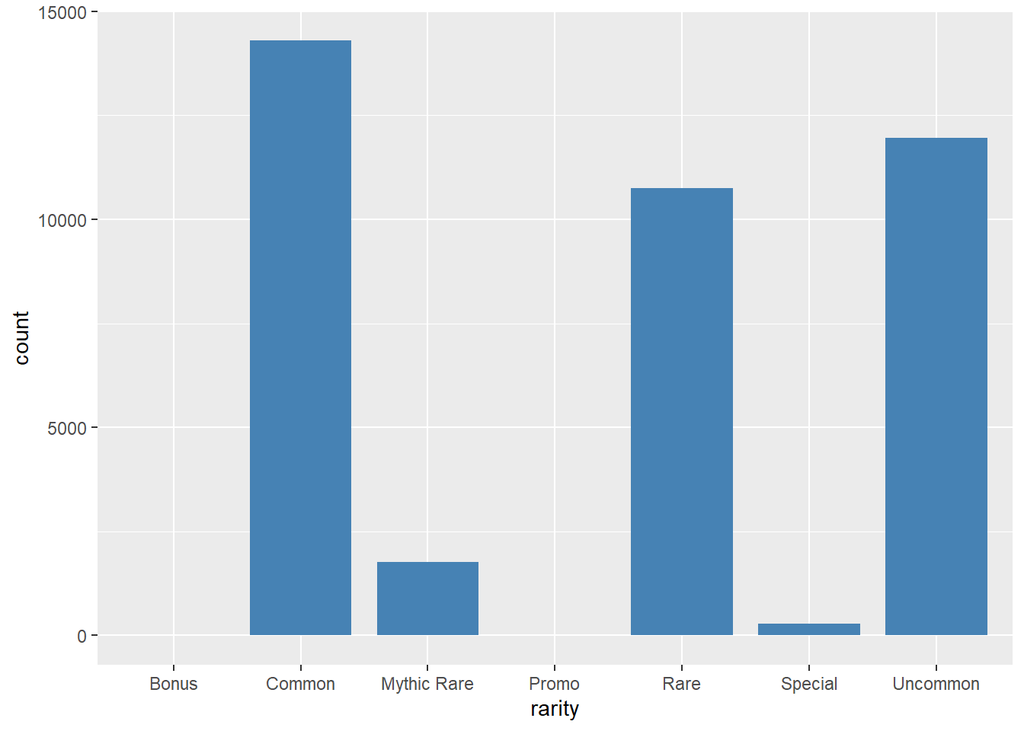

```
## # A tibble: 7 x 2
##   rarity      count
##   <chr>       <int>
## 1 Bonus           9
## 2 Common      14295
## 3 Mythic Rare  1757
## 4 Promo           1
## 5 Rare        10746
## 6 Special       278
## 7 Uncommon    11964
```

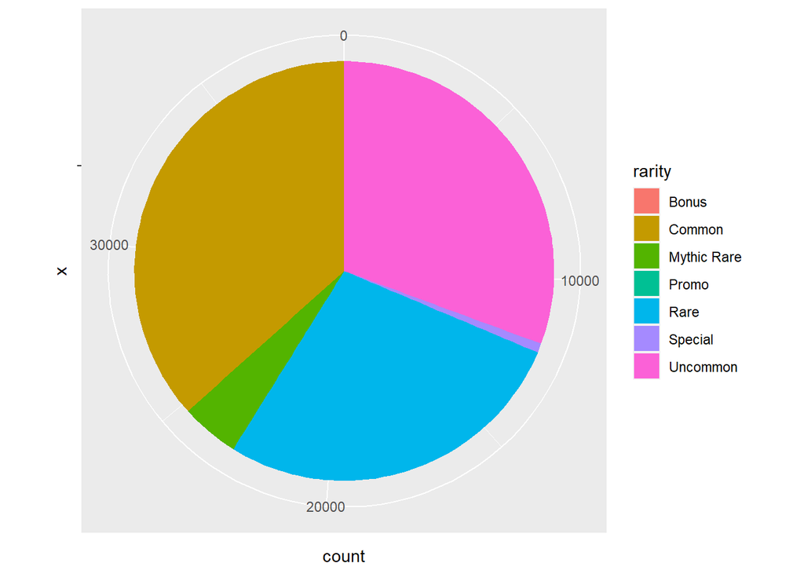

##### And lastly by type

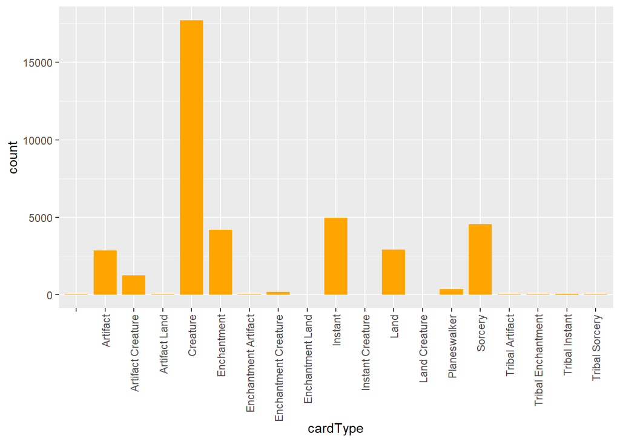

### Bivariate Exploration

##### My first exploration of two variables was converted mana cost faceted on card type to see where the bulk of my data fell

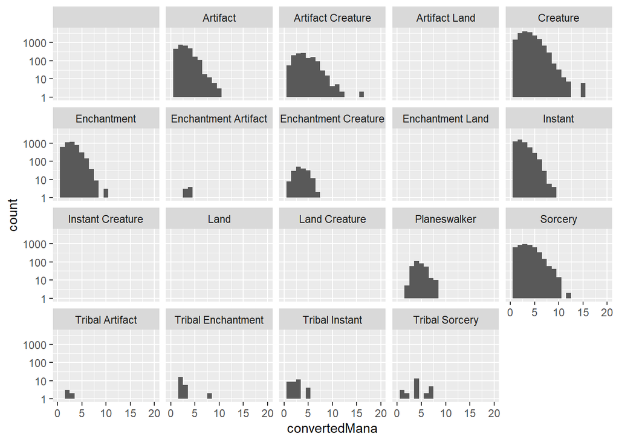

##### From that histogram I can see there are a few very sparse cardtypes. I may roll them into some of the more popularly occuring types

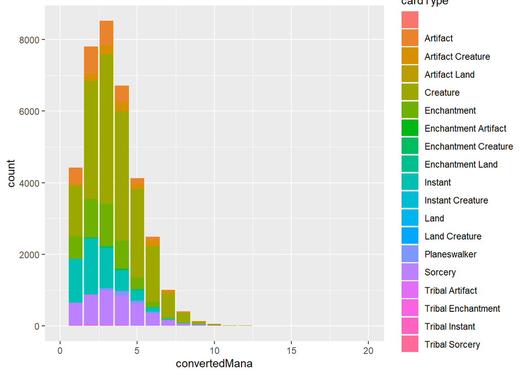

#### Coverted Mana Cost Density by Rarity

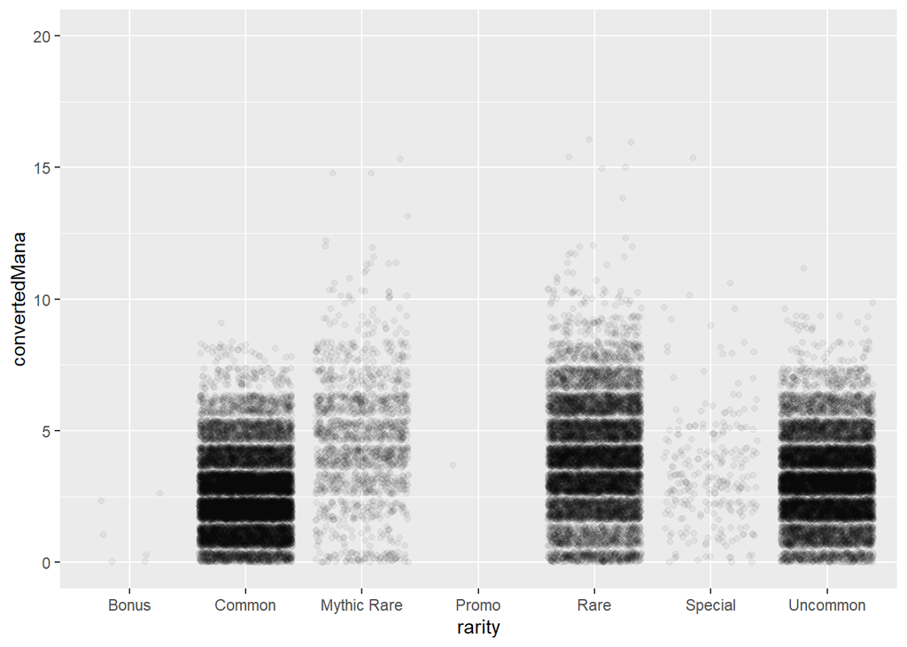

##### I then did a density check by rarity, which uncovered 3 groups I didn’t want to use in this dataset: Bonus, Promo, and Special

```
## # A tibble: 54 x 3
## # Groups:   rarity [4]
##    rarity convertedMana count
##    <chr>          <int> <int>
##  1 Common             0  1366
##  2 Common             1  2499
##  3 Common             2  3825
##  4 Common             3  3288
##  5 Common             4  1817
##  6 Common             5   975
##  7 Common             6   391
##  8 Common             7    99
##  9 Common             8    34
## 10 Common             9     1
## # ... with 44 more rows
```

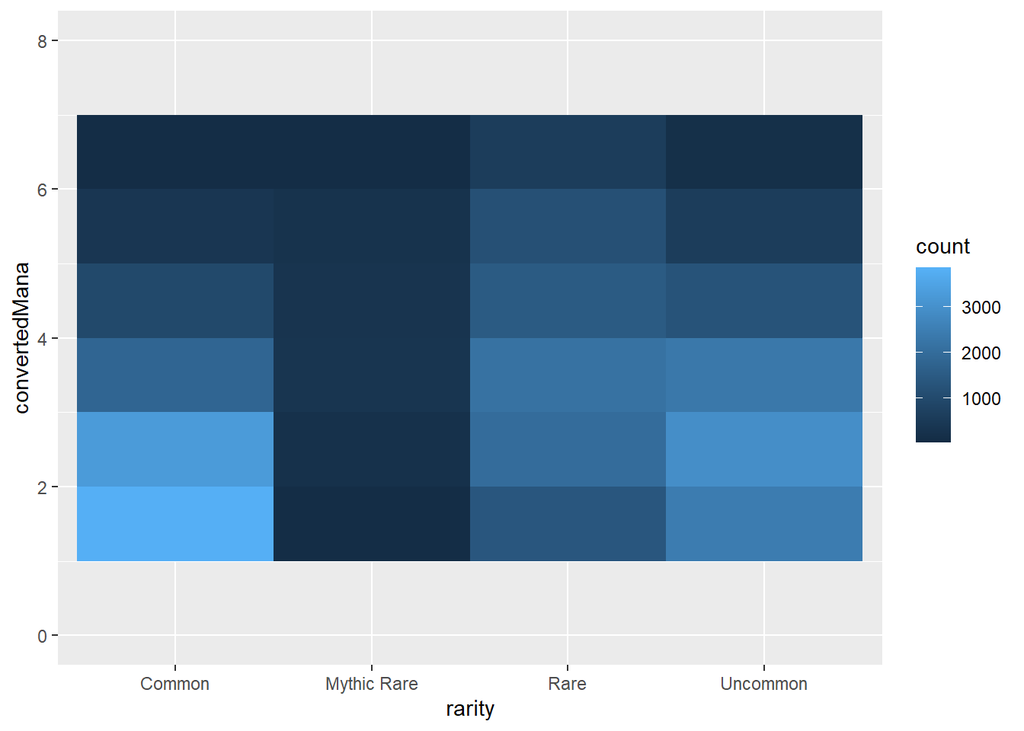

##### I performed a check on the 99% Quantile of each card types CMC. Now with the three undesired rarities removed

##### At this point I stripped out the 3 extra rarities, and then grouped each rarity by CMC

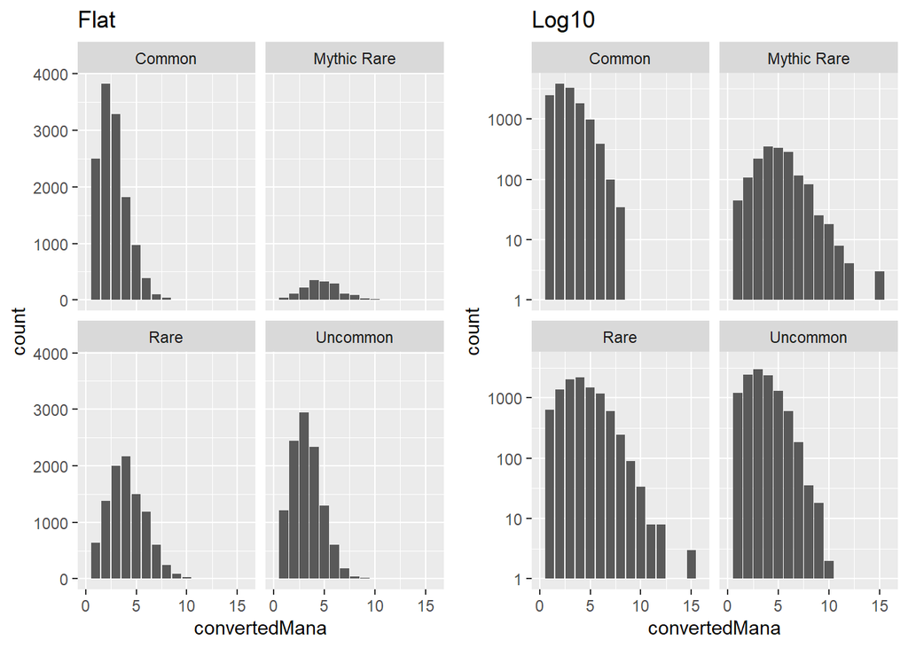

##### These Two graphs give a breakdown on where data falls by rarity.

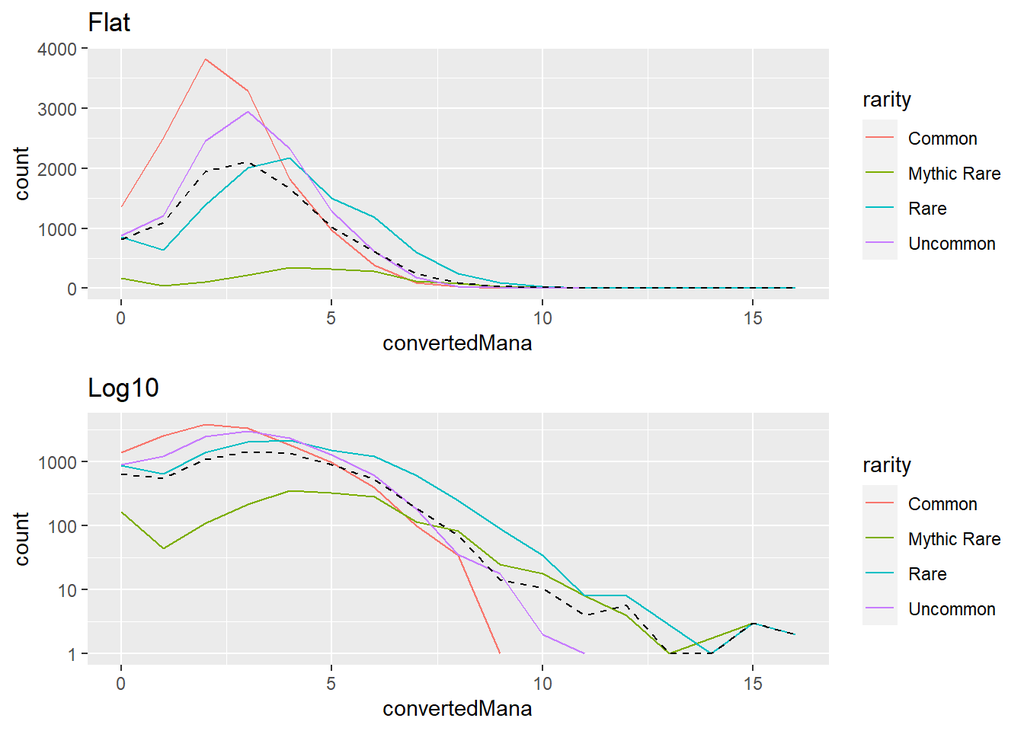

##### And this is the same data, overlaid plus a dashed line for the mean value

```
##        rarity    0    1    2    3    4    5    6   7   8  9 10 11 12 13 14 15
## 1      Common 1366 2499 3825 3288 1817  975  391  99  34  1 NA NA NA NA NA NA
## 2 Mythic Rare  164   44  108  218  352  328  286 115  83 25 18  8  4  1 NA  3
## 3        Rare  861  637 1382 2004 2171 1501 1190 607 246 90 34  8  8 NA  1  3
## 4    Uncommon  885 1211 2448 2949 2332 1290  608 185  35 18  2  1 NA NA NA NA
##   16 1000000
## 1 NA      NA
## 2 NA      NA
## 3  2       1
## 4 NA      NA
```

#### Exploring Card Subtypes

##### There was an issue where subtypes could consist of a handful of words; I created a separate set of subtypes that I’m going to use to query I’m hoping that I can find certain subtypes that have been abandoned Also, I would like to see the most popular Subtypes.

```
##   [1] ""              "Shapeshifter"  "Zombie"        "Gargoyle"
##   [5] "Griffin"       "Human"         "Cleric"        "Monk"
##   [9] "Aura"          "Insect"        "Demon"         "Abian"
##  [13] "Eldrazi"       "Vampire"       "Treefolk"      "Horror"
##  [17] "Elf"           "Elemental"     "Cephalid"      "Noble"
##  [21] "Thrull"        "Art"           "Lizard"        "Cat"
##  [25] "Leech"         "Assassin"      "Nightstalker"  "Specter"
##  [29] "Dog"           "Shaman"        "Soldier"       "Warrior"
##  [33] "Bird"          "Drake"         "Wizard"        "Contraption"
##  [37] "Knight"        "Construct"     "Equipment"     "Centaur"
##  [41] "Spirit"        "Spider"        "Ooze"          "Sliver"
##  [45] "Dragon"        "Squirrel"      "Rogue"         "Beast"
##  [49] "Unicorn"       "Angel"         "Illusion"      "Goblin"
##  [53] "Pirate"        "Scout"         "Drone"         "Turtle"
##  [57] "Avatar"        "Berserker"     "Artificer"     "Dwarf"
```

[output cut: 76 more lines]

##### With my new Dataset I created a separated list of the subtypes, I also created a single array of values to see them more space-efficiently

```
## # A tibble: 1,434 x 2
##    subType             n
##    <chr>           <int>
##  1 ""              15924
##  2 "Aura"           1772
##  3 "Human Wizard"    705
##  4 "Elemental"       654
##  5 "Human Soldier"   603
##  6 "Spirit"          506
##  7 "Equipment"       479
##  8 "Beast"           438
##  9 "Angel"           373
## 10 "Human Cleric"    366
## # ... with 1,424 more rows
```

##### Here we have all of the different subtypes, tallied. I see human appears in 3 of these entries, so I want to split it further

```
##      subType frequency
## 1                23126
## 2      Human      3931
## 3       Aura      1819
## 4          B      1506
## 5     Wizard      1282
## 6    Warrior      1216
## 7    Soldier      1105
## 8  Elemental       925
## 9        Elf       833
## 10    Zombie       794
## 11    Spirit       754
## 12    Goblin       751
## 13    Shaman       710
## 14     Beast       653
## 15    Cleric       638
```

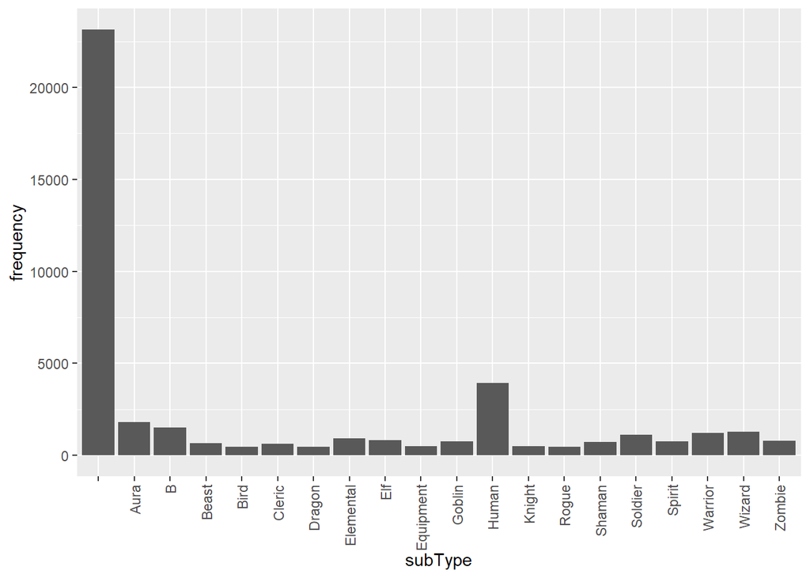

##### The head of the list, and the subsequent plot show the tallies by individual word; I can see at a glance that things like B and " " are oddballs, so I’m going to selectively remove them.

```
##      subType frequency
## 1      Human      3931
## 2       Aura      1819
## 3     Wizard      1282
## 4    Warrior      1216
## 5    Soldier      1105
## 6  Elemental       925
## 7        Elf       833
## 8     Zombie       794
## 9     Spirit       754
## 10    Goblin       751
## 11    Shaman       710
## 12     Beast       653
## 13    Cleric       638
## 14    Knight       506
## 15 Equipment       485
```

##### With this I can see a more useful spread of data

#### Using Split subtypes to Summarize CMC

##### For this section I want to take the work I did with splitting subtypes, and apply it to each row, creating a summary of a few important stats.

##### Human Summary

```
##    cardName           subType          convertedMana      rarity
##  Length:3931        Length:3931        Min.   :0.000   Length:3931
##  Class :character   Class :character   1st Qu.:2.000   Class :character
##  Mode  :character   Mode  :character   Median :3.000   Mode  :character
##                                        Mean   :3.068
##                                        3rd Qu.:4.000
##                                        Max.   :8.000
```

##### Wizard Summary

```
##    cardName           subType          convertedMana      rarity
##  Length:1282        Length:1282        Min.   :0.000   Length:1282
##  Class :character   Class :character   1st Qu.:2.000   Class :character
##  Mode  :character   Mode  :character   Median :3.000   Mode  :character
##                                        Mean   :3.236
##                                        3rd Qu.:4.000
##                                        Max.   :8.000
```

##### Soldier Summary

```
##    cardName           subType          convertedMana      rarity
##  Length:1105        Length:1105        Min.   :0.000   Length:1105
##  Class :character   Class :character   1st Qu.:2.000   Class :character
##  Mode  :character   Mode  :character   Median :3.000   Mode  :character
##                                        Mean   :3.165
##                                        3rd Qu.:4.000
##                                        Max.   :8.000
```

##### Elf Summary

```
##    cardName           subType          convertedMana     rarity
##  Length:833         Length:833         Min.   :0.00   Length:833
##  Class :character   Class :character   1st Qu.:2.00   Class :character
##  Mode  :character   Mode  :character   Median :3.00   Mode  :character
##                                        Mean   :2.86
##                                        3rd Qu.:4.00
##                                        Max.   :7.00
```

##### Zombie Summary

```
##    cardName           subType          convertedMana      rarity
##  Length:794         Length:794         Min.   :0.000   Length:794
##  Class :character   Class :character   1st Qu.:3.000   Class :character
##  Mode  :character   Mode  :character   Median :3.000   Mode  :character
##                                        Mean   :3.565
##                                        3rd Qu.:5.000
##                                        Max.   :9.000
```

##### Dragon Summary

```
##    cardName           subType          convertedMana       rarity
##  Length:459         Length:459         Min.   : 1.000   Length:459
##  Class :character   Class :character   1st Qu.: 5.000   Class :character
##  Mode  :character   Mode  :character   Median : 6.000   Mode  :character
##                                        Mean   : 5.978
##                                        3rd Qu.: 7.000
##                                        Max.   :16.000
```

##### Eldrazi Summary

```
##    cardName           subType          convertedMana       rarity
##  Length:180         Length:180         Min.   : 0.000   Length:180
##  Class :character   Class :character   1st Qu.: 3.000   Class :character
##  Mode  :character   Mode  :character   Median : 4.500   Mode  :character
##                                        Mean   : 5.194
##                                        3rd Qu.: 8.000
##                                        Max.   :15.000
```

### Multivariate Exploration

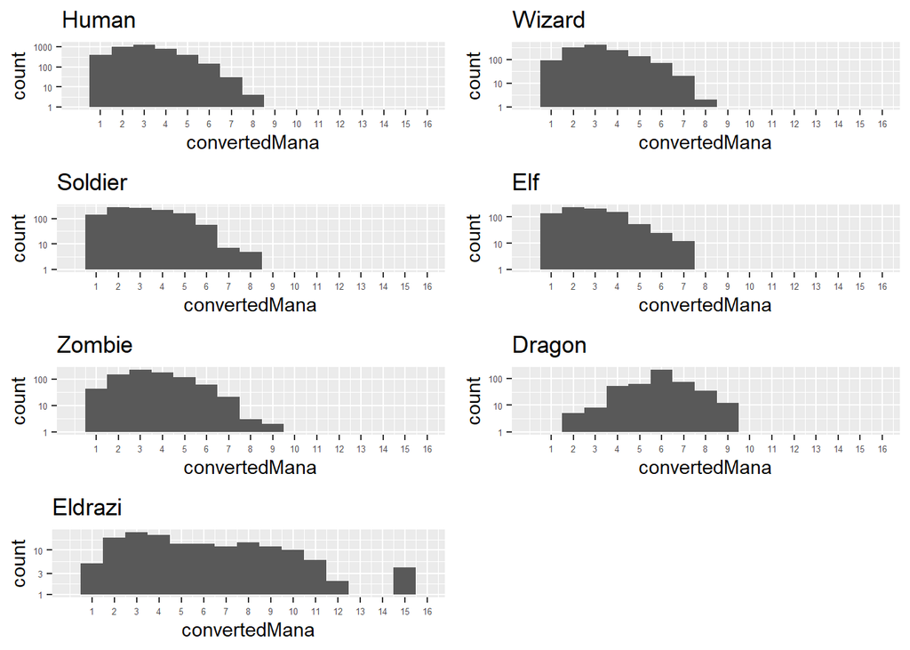

##### From my sampling of 7 subtypes, it appears that whereas the counts may be different, the relative data dispersal remains similar, with a somewhat normalized distribution.

##### Costs seem to be centered/balanced around the 2-4 cost cards, though you can see that certain subtypes are trending into higher brackets.

```
##                                  cardName          subType convertedMana
## 1                         Apex Devastator    Chimera Hydra            10
## 2                         Autochthon Wurm             Wurm            15
## 3  B.F.M. (Big Furry Monster, Right Side)                             15
## 4                               Broodstar            Beast            10
## 5              Decimator of the Provinces     Eldrazi Boar            10
## 6                         Deep-Sea Kraken           Kraken            10
## 7                         Desolation Twin          Eldrazi            10
## 8                           Dragon Tyrant           Dragon            10
## 9                         Dread Cacodemon            Demon            10
## 10                Emrakul, the Aeons Torn          Eldrazi            15
## 11              Emrakul, the Promised End          Eldrazi            13
## 12                  Ghalta, Primal Hunger   Elder Dinosaur            12
## 13                       Greater Gargadon            Beast            10
## 14                                 Hypnox Nightmare Horror            11
## 15                   Impervious Greatwurm             Wurm            10
```

##### It’s interesting to see, that in the top returned values only a few of the 7 sampled subtypes appear.

```
## # A tibble: 303 x 4
##    subType          n   max convertedMana
##    <chr>        <int> <int>         <dbl>
##  1 Adventure       31     7          2.52
##  2 Ajani           19     6          4.47
##  3 Angel          373     9          5.56
##  4 Angel Spirit    18     5          3.06
##  5 Antelope        13     5          3.31
##  6 Ape             34     8          3.97
##  7 Arcane         138     6          2.82
##  8 Archon          29     9          6.03
##  9 Atog            19     6          2.84
## 10 Aura          1772     8          2.49
## # ... with 293 more rows
```

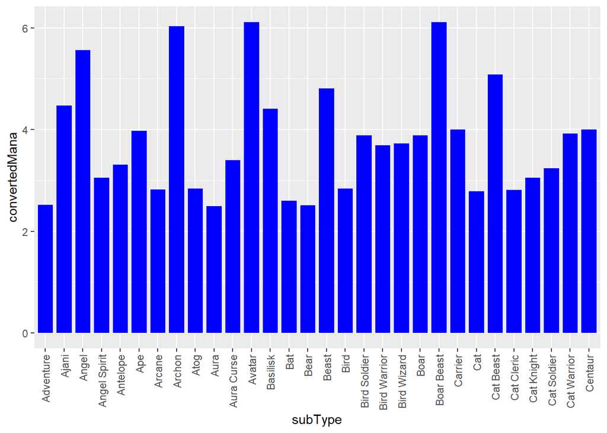

```
## # A tibble: 87 x 5
##    subType          n   max median convertedMana
##    <chr>        <int> <int>  <dbl>         <dbl>
##  1 Angel          373     9      5          5.56
##  2 Arcane         138     6      3          2.82
##  3 Aura          1772     8      2          2.49
##  4 Avatar          95    11      6          6.12
##  5 Beast          438    10      5          4.81
##  6 Bird           247     7      2          2.84
##  7 Bird Soldier    69     6      4          3.88
##  8 Cat            141     6      3          2.79
##  9 Construct      253    11      3          3.63
## 10 Demon          154    10      6          5.69
## # ... with 77 more rows
```

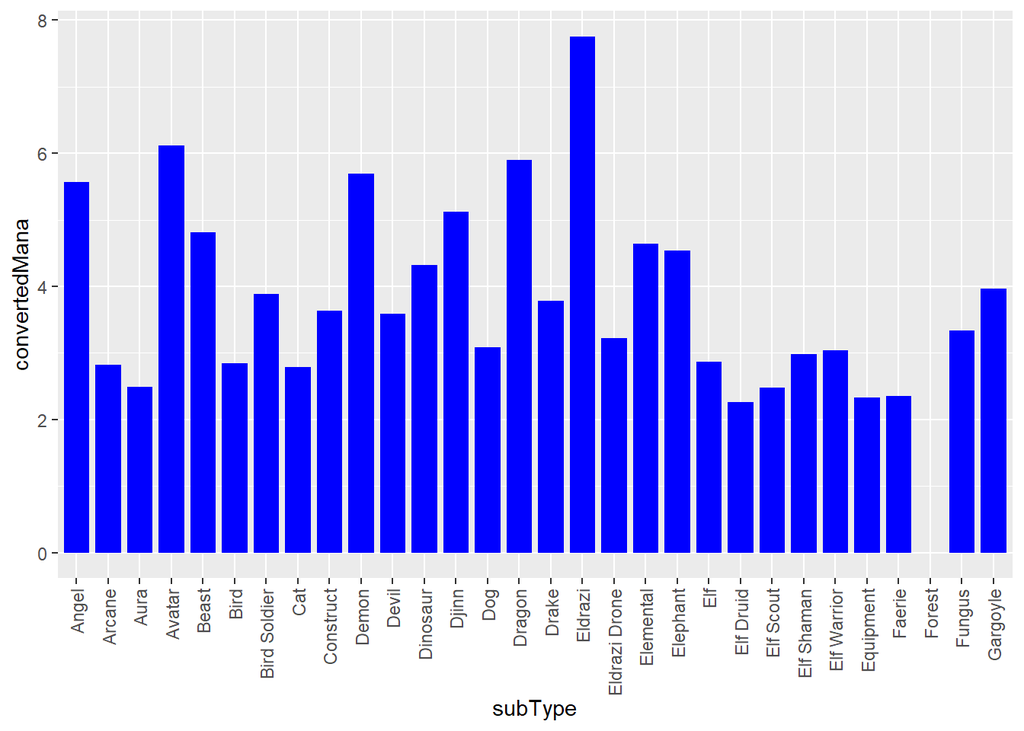

```
## # A tibble: 19 x 4
##    subType           n   max convertedMana
##    <chr>         <int> <int>         <dbl>
##  1 Angel           373     9          5.56
##  2 Aura           1772     8          2.49
##  3 Beast           438    10          4.81
##  4 Bird            247     7          2.84
##  5 Construct       253    11          3.63
##  6 Dragon          342    16          5.90
##  7 Elemental       654     9          4.64
##  8 Equipment       479     7          2.33
##  9 Goblin          228     5          2.53
## 10 Golem           222    12          5.33
## 11 Human Cleric    366     7          2.63
## 12 Human Knight    327     8          3.26
## 13 Human Soldier   603     7          3.04
## 14 Human Warrior   280     7          3.19
## 15 Human Wizard    705     8          3.06
## 16 Insect          211     7          3.36
## 17 Spirit          506    12          3.71
## 18 Wall            242     7          2.88
## 19 Zombie          347     9          3.36
```

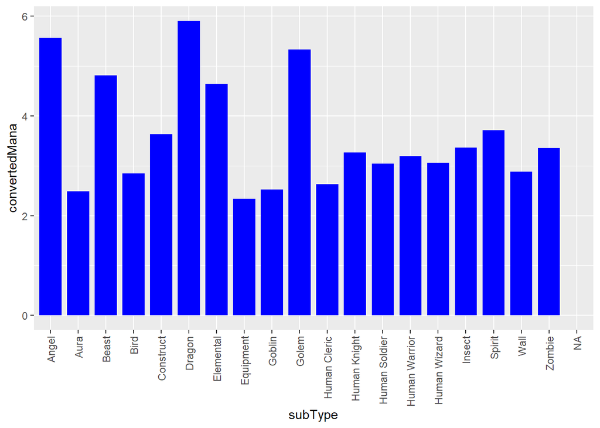

##### I think that some more valuable observations can be made by expanding back out of the sample, and searching for some other observations from the whole subtype data column, SO I did a check for the Mean CMC as well as the count of each Subtype with various levels of strictness for minimum subtype counts

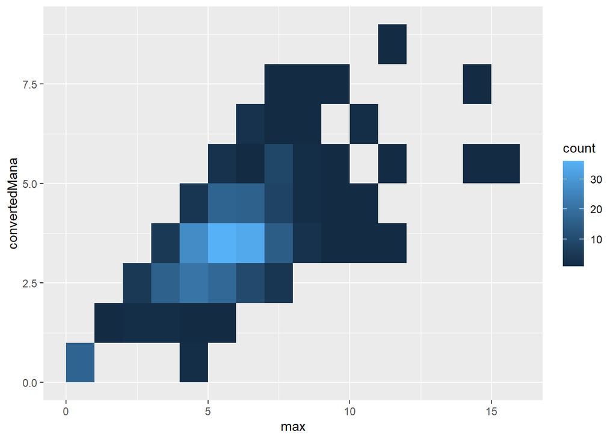

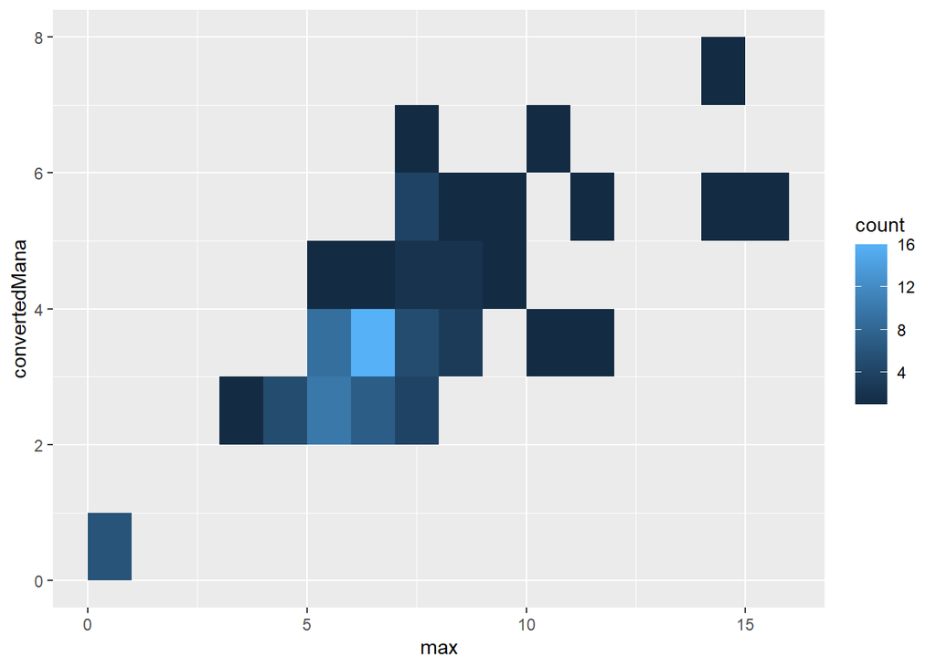

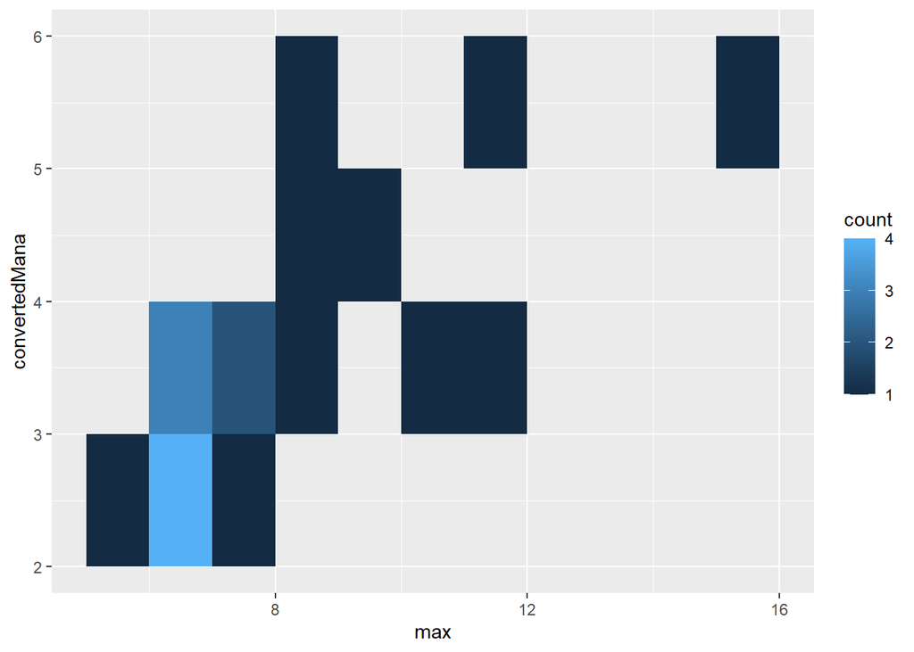

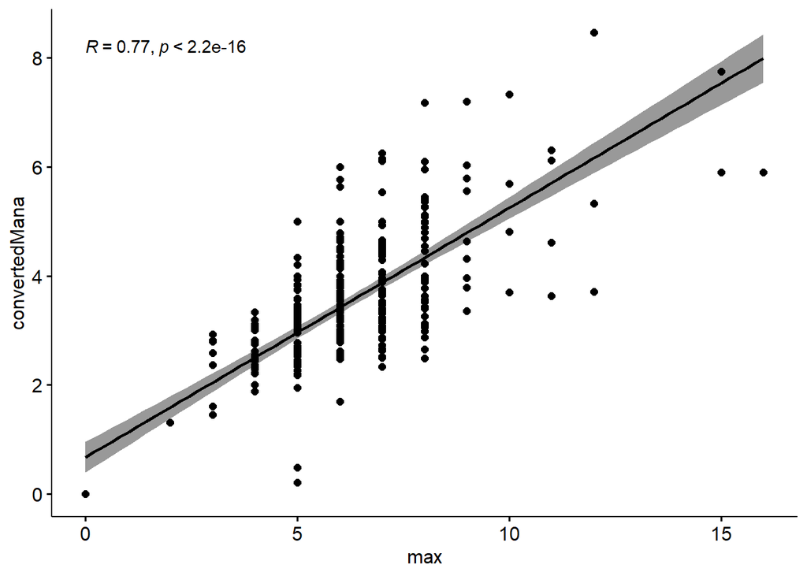

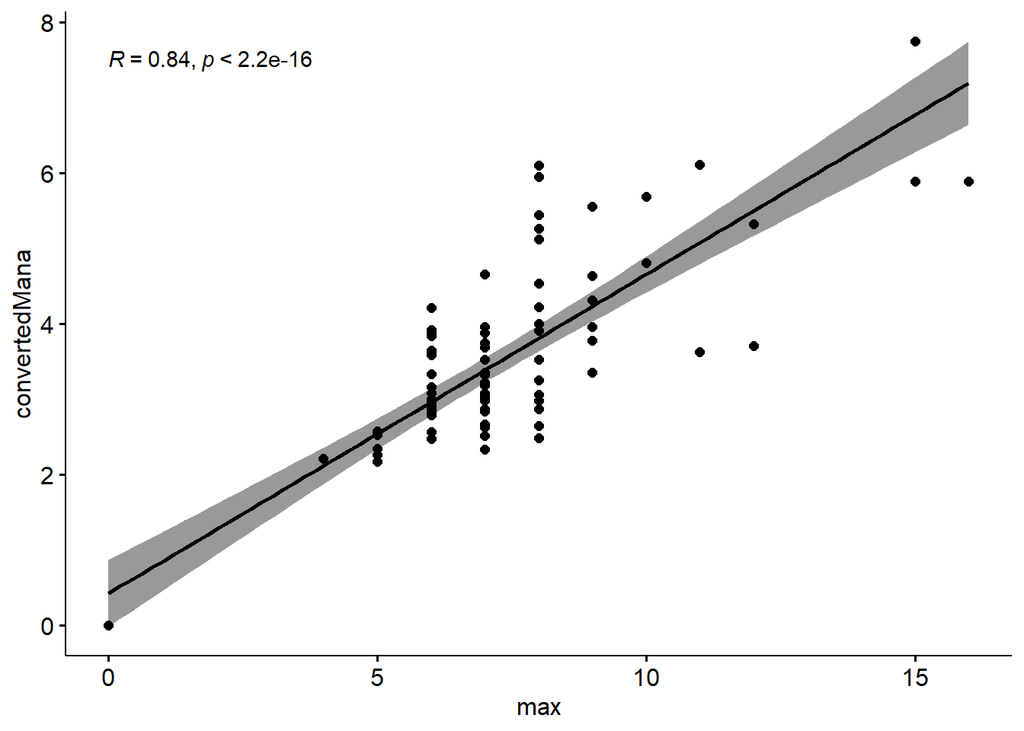

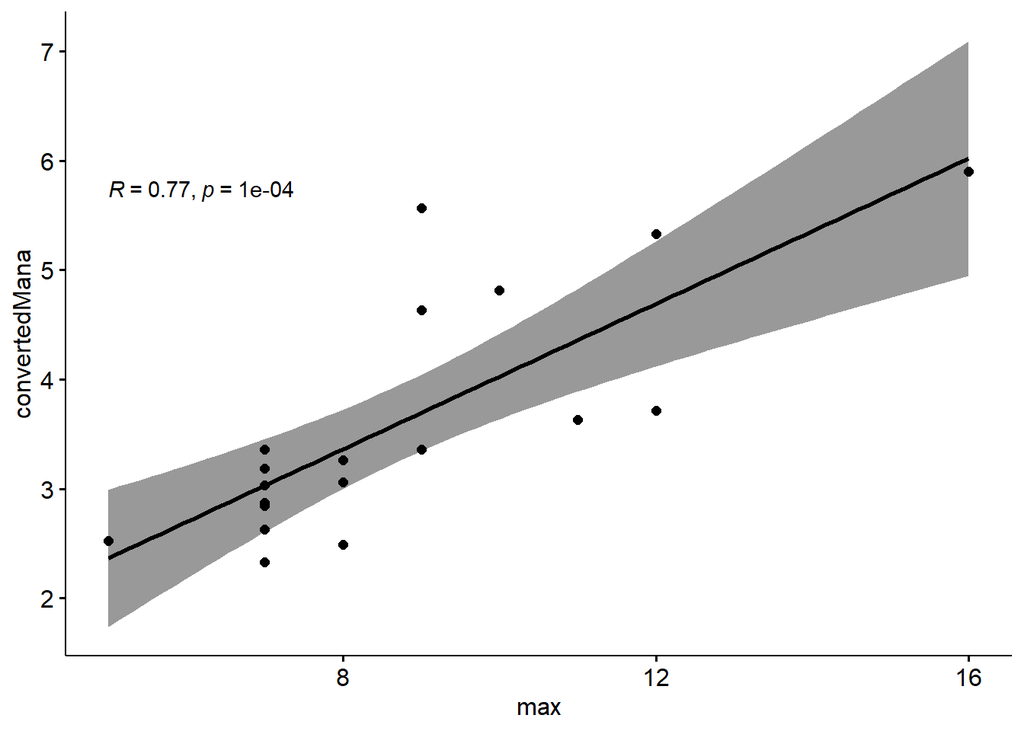

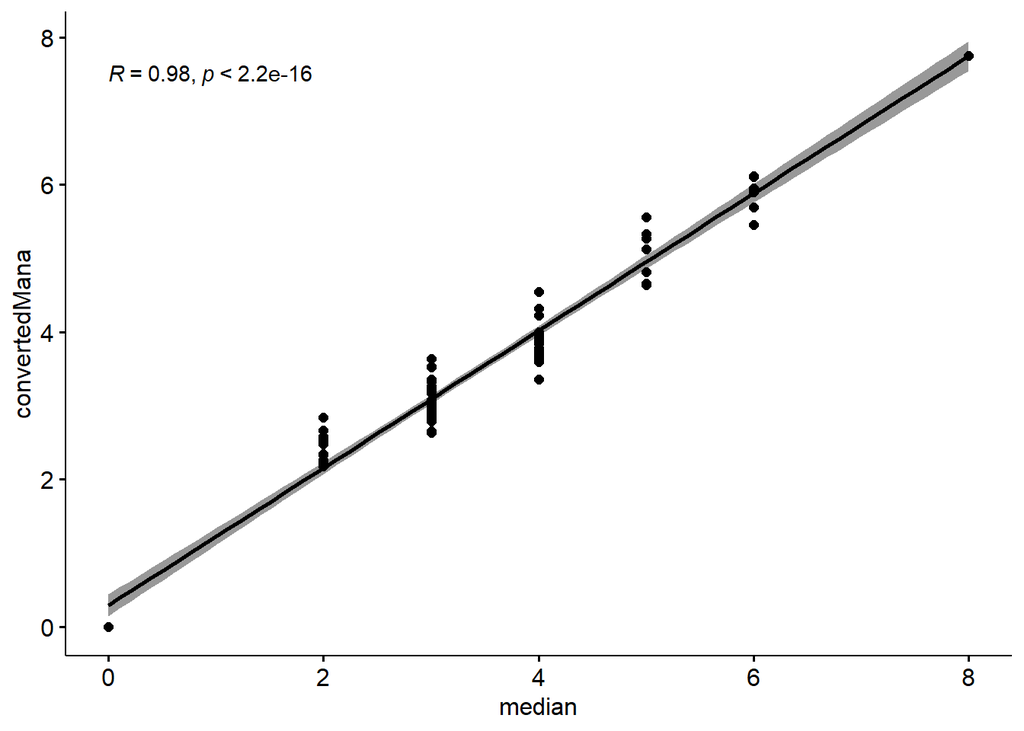

##### The three graphs above check the lax, strict and strictest datasets for correlation via pearsons R. All are above .7 so all have a strong relationship. I also decided to go back and added median as a measured variable. The Last graph shows just how effective that was, which makes sense, certainly; with some subtypes having hundreds of results though a .98 correlation was a little surprising.

[figure not shown]

#### Analysis One: Creature Types and Cost Distribution

```
## # A tibble: 71 x 3
## # Groups:   convertedMana [16]
##    convertedMana count subtype
##            <int> <int> <chr>
##  1             0    10 Human
##  2             1   401 Human
##  3             2   981 Human
##  4             3  1226 Human
##  5             4   758 Human
##  6             5   380 Human
##  7             6   140 Human
##  8             7    31 Human
##  9             8     4 Human
## 10             0     1 Wizard
## # ... with 61 more rows
```

```
##   subtype  0   1   2    3   4   5   6  7  8  9 10 11 12 13 15 16
## 1  Dragon NA   1   5    8  52  61 208 74 35 12  1 NA NA NA NA  2
## 2 Eldrazi 19   5  19   25  22  14  14 12 15 12 10  6  2  1  4 NA
## 3     Elf  1 135 232  215 160  54  24 12 NA NA NA NA NA NA NA NA
## 4   Human 10 401 981 1226 758 380 140 31  4 NA NA NA NA NA NA NA
## 5 Soldier  3 139 272  256 213 155  55  7  5 NA NA NA NA NA NA NA
## 6  Wizard  1  92 318  406 239 134  70 20  2 NA NA NA NA NA NA NA
## 7  Zombie  3  44 151  218 178 114  60 21  3  2 NA NA NA NA NA NA
```

##### Taking an analysis I did earlier on some sampled subtypes in separate graphs, I decided to perform some merging and then overlay the results.

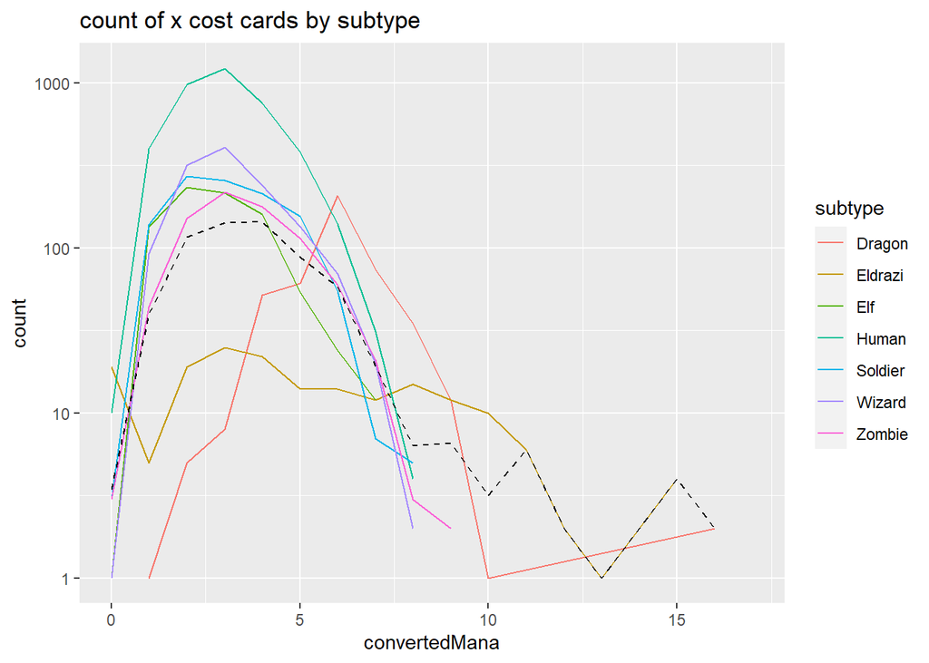

##### the values displayed indicate that if you play Magic based solely on subtype you will not be able to reliably maintain the same play pace. Some will naturally require more investment in order to get going. Different subtypes have their own distinct value pattern by Converted mana cost

#### Analysis Two

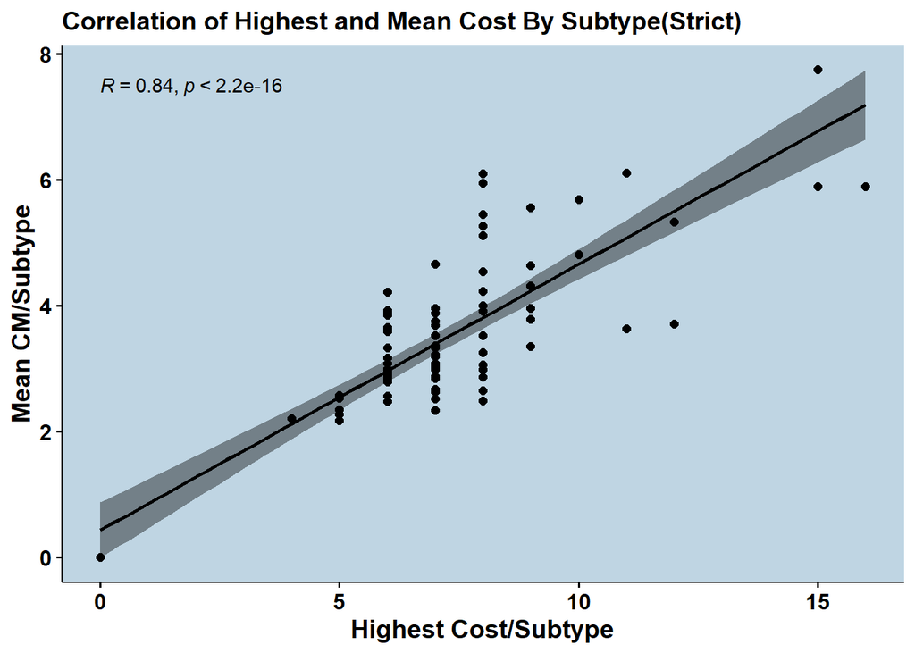

##### The Graph above indicates that whereas there ARE outliers, to be certain, more of the data does follow a trend of sticking close to its highest value. I opted not to use median in the final analysis because whereas it does have a higher correlation, I also wasn’t as surprised by the result of creating that graph.

#### Analysis Three

```
## $title
## [1] "Density of Cards(Rare and Mythic Rare)"
##
## attr(,"class")
## [1] "labels"
```

```
## # A tibble: 22 x 3
## # Groups:   rarity [3]
##    rarity      subType       count
##    <chr>       <chr>         <int>
##  1 Mythic Rare Angel            37
##  2 Mythic Rare Demon            22
##  3 Mythic Rare Dragon           21
##  4 Mythic Rare Elder Dragon     10
##  5 Mythic Rare Eldrazi          11
##  6 Mythic Rare Elemental        22
##  7 Mythic Rare Human Cleric     10
##  8 Mythic Rare Human Shaman     12
##  9 Mythic Rare Human Warrior    14
## 10 Mythic Rare Human Wizard     22
## # ... with 12 more rows
```

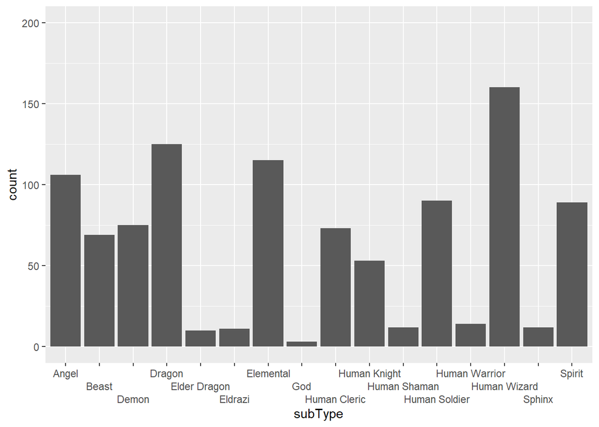

##### The above is a selection of Rare and above cards, and their relative counts. Your chances of a rare(+) Human Wizard, or Dragon far exceed something like a Sphinx, or God.

### Reflection

##### This dataset was nearly 40,000 cards, Spanning almost 30 years that the game has existed. My goals at the onset were to find some trends based on my own experiences with the game. the two largest were relations between Rarity and CMC, and the general cost trends by subtype. Some of my attempts were ridiculously unsuccessful, resulting in datasets of 0, or in one case 55 million, which I didn’t see as practical.

##### R feels like a powerful (and quick) tool that gives its users a great handful of approaches to the same problem; In my case that was more of a burden than a boon as I never felt like I’d analyzed my dataset in the ‘best’ way.

##### I Was hoping to create buckets that contained multiple matching values (subtypes appearing more than once if they matched the stripped down, single word subtypes). I’ll need to perform further research on my own time.

##### I would have liked a year-released column, as that would have provided some interesting insights for which card subtypes had the greatest longevity. Having the artist for the cards would be neat too, to determine who Wizards of the Coast used most often.

### Resources

http://zevross.com/blog/2014/08/04/beautiful-plotting-in-r-a-ggplot2-cheatsheet-3/

http://r-statistics.co/Top50-Ggplot2-Visualizations-MasterList-R-Code.html